# Reproducible Research - Course Project 1

## Introduction

The purpose of this project is to analyse activity data obtained from a personal monitoring device. The data was collected at 5 minute intervals during the day for a period of two months.

### Loading and pre-processing the data

First we need to load some libraries:

```r
library(dplyr)
library(lubridate)
library(ggplot2)
```

Next we load the data:

```r
df0 <- read.csv('activity.csv', header = TRUE, sep = ",")
```

Now, we’ll perform a few transformations to prepare the data for further analysis:

```r
# split data per day
stepsDay <- split(df0$steps, df0$date)

# create dataframe (each day is an observation, each column is a time period)
df1 <- data.frame(matrix(unlist(stepsDay), nrow=61, byrow=T),stringsAsFactors=FALSE)

# rename columns of new dataframe
names(df1) <- unique(factor(df0$interval))

# add column with dates
df1 <- cbind(Date = ymd(unique(df0$date)), df1)
```

### What is the mean total number of steps taken per day?

For this part of the assignment we will ignore the missing values (NA’s)

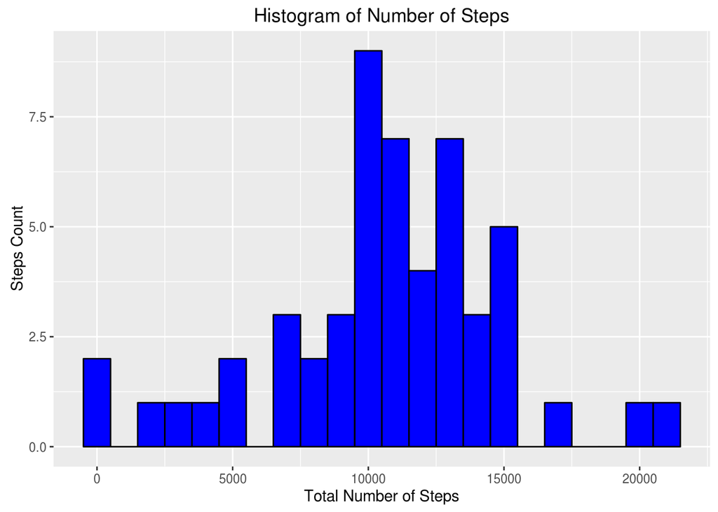

```r
# add columns with total number of steps per day
df1 <- cbind(df1, Total.Steps = rowSums(df1[,2:289]))

# histogram of total number of steps taken each day
plt <- ggplot(df1, aes(df1$Total.Steps))
plt + geom_histogram(binwidth = 1000, color = "black", fill = "blue") + xlab("Total Number of Steps") + ylab("Steps Count") +
  ggtitle("Histogram of Number of Steps")
```

The mean and median steps are (in that order):

```r
# mean and median number of steps per day
stepsMean <- mean(df1$Total.Steps, na.rm = TRUE)
stepsMedian <- median(df1$Total.Steps, na.rm = TRUE)
```

```
## [1] 10766.19
```

```
## [1] 10765
```

### What is the average daily activity pattern?

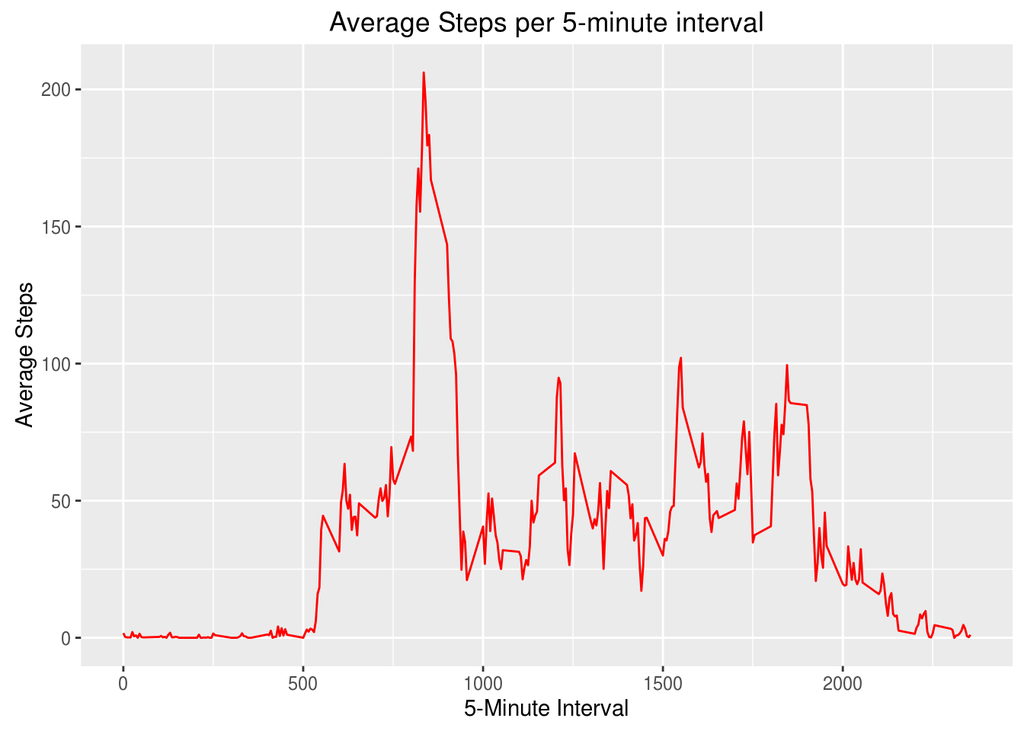

```r
# remove days with no data recorded
df2 <- filter(df1, !is.na(Total.Steps))

# average across days for each interval
intervalAvg <- apply(df2[,2:289], 2, mean)

# create addtional dataframe for time series plot
df22 <- data.frame(row.names = as.character(c(1:288)))
df22 <- cbind(df22, as.numeric(unique(df0$interval)), intervalAvg)
names(df22) <- c("Interval", "Average")

# time series plot of 5-minute intervals vs average of steps for each interval across days
plt <- ggplot(df22, aes(x = Interval, y = Average))
plt + geom_line(color = "red") + xlab("5-Minute Interval") + ylab("Average Steps") +
  ggtitle("Average Steps per 5-minute interval")
```

```r
# find 5-minute interval with maximum number of steps
fiveMinInt <- which(intervalAvg %in% max(intervalAvg))
```

```
## [1] 104
```

### Imputing missing values

The total number of rows with missing values (NA’s) is:

```r
# number of rows with NA's
numNAs <- length(df1$Total.Steps[is.na(df1$Total.Steps)])
```

```
## [1] 8
```

Next, we will recreate the original dataset but this time we will use the mean of 5-minute intervals averaged across days to fill in the missing data

```r
# recreate original but with missing data filled in
df3 <- data.frame(matrix(unlist(stepsDay), nrow=61, byrow=T),stringsAsFactors=FALSE)

# obtain indexes of rows with NA's
idx <- which(is.na(df1$Total.Steps))

# replace rows with missing NA's with mean of 5-minute intervals averaged across days
for (i in idx){
  df3[i,] <- unname(intervalAvg)
}
```

So the new mean and medians are:

```r
# add columns with total number of steps per day
df3 <- cbind(df3, Total.Steps = rowSums(df3))

# add column with dates
df3 <- cbind(Date = ymd(unique(df0$date)), df3)

# mean and median number of steps per day
stepsMean2 <- mean(df3$Total.Steps, na.rm = TRUE)
stepsMedian2 <- median(df3$Total.Steps, na.rm = TRUE)
```

```
## [1] 10766.19
```

```
## [1] 10766.19
```

And the new histogram is:

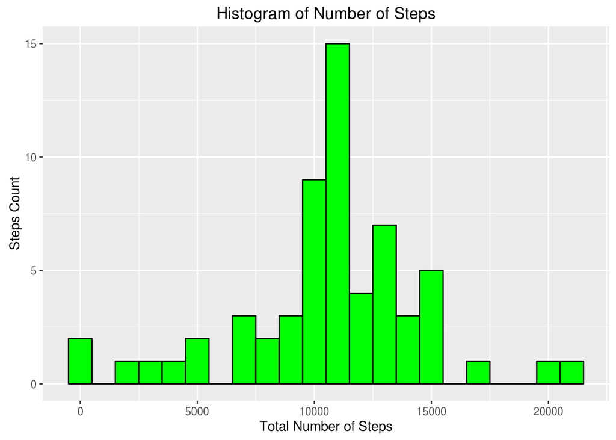

```r
# histogram of total number of steps taken each day
plt <- ggplot(df3, aes(Total.Steps))
plt + geom_histogram(binwidth = 1000, color = "black", fill = "green") + xlab("Total Number of Steps") + ylab("Steps Count") +
  ggtitle("Histogram of Number of Steps")
```

### Are there differences in activity patterns between weekdays and weekends?

First we’ll discriminate the rows in our dataset according to the categories “Weekday/Weekend”

```r
# add column with factor levels "weekday/weekend"
a <- weekdays(df3$Date, abbreviate = TRUE)
b <- gsub("S(at|un)", "Weekend", a)
b[grep("end", b, invert = TRUE)] <- "Weekday"
df3 <- cbind(df3, b)

# rename columns of new dataframe
names(df3) <- c(names(df2), "Weekday-Weekend")
```

Next, we’ll calculate the average of the 5-minute interval for both weekdays and weekends

```r
df3_wd <- filter(df3, df3$`Weekday-Weekend` == "Weekday")
df3_we <- filter(df3, df3$`Weekday-Weekend` == "Weekend")

# average across days for each interval
intervalAvg_we <- apply(df3_we[,2:289], 2, mean)
intervalAvg_wd <- apply(df3_wd[,2:289], 2, mean)
```

Finally, we’ll manipulate this data to create a new data frame to plot the data

```r
# create addtional dataframe for time series plot
df33_wd <- data.frame(row.names = as.character(c(1:288)))
df33_wd <- cbind(df33_wd, as.numeric(unique(df0$interval)), rep(c("Weekday"), 288), intervalAvg_wd)
names(df33_wd) <- c("Interval", "Weekday-Weekend", "Average")

df33_we <- data.frame(row.names = as.character(c(1:288)))
df33_we <- cbind(df33_we, as.numeric(unique(df0$interval)), rep(c("Weekend"), 288), intervalAvg_we)
names(df33_we) <- c("Interval", "Weekday-Weekend", "Average")

df33 <- rbind(df33_wd, df33_we)
```

Now we can plot the 5-minute interval averaged across days of the week and weekends in a panel plot

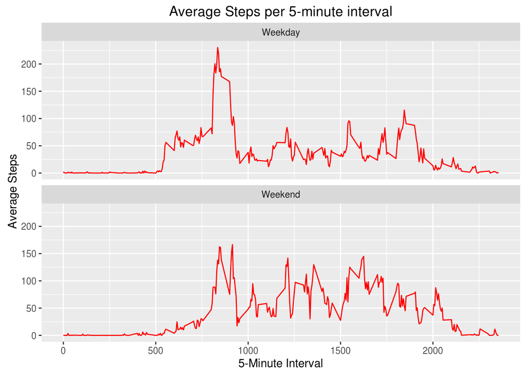

```r
# time series plot of the 5-minutes interval and the average number of steps taken, averaged across weekdays or weekends
plt <- ggplot(df33, aes(x=Interval, y=Average))
plt + geom_line(color = "red") + facet_wrap(~`Weekday-Weekend`, ncol = 1) + xlab("5-Minute Interval") + ylab("Average Steps") +
  ggtitle("Average Steps per 5-minute interval")
```